# Multi-cue recall (v3.3)

## Participants

- N = 10

## Probability of remembering first word

As a sanity check, we first ask if our memory strength index predicts participants choices about which image to recall. We operationalize memory strength as the within-participant, Z-scored, mean-log 2AFC RT (that’s a mouthful!)

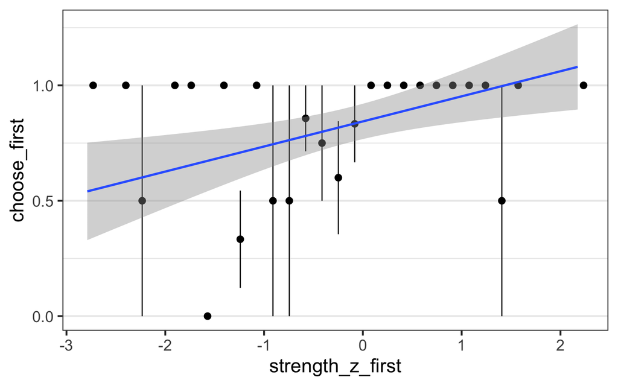

```r
ggplot(multi, aes(strength_z_first, choose_first)) +
    stat_summary_bin() + geom_smooth(method='lm')
```

```r
lmer(choose_first ~ strength_z_first + (1|wid), data=multi) %>% summ
```

| Fixed Effects | Fixed Effects Est. | Fixed Effects S.E. | Fixed Effects t val. | Fixed Effects d.f. | Fixed Effects p |
| --- | --- | --- | --- | --- | --- |
| (Intercept) | 0.844 | 0.058 | 14.523 | 9.096 | 0.000 |
| strength_z_first | 0.115 | 0.035 | 3.315 | 80.590 | 0.001 |

p values calculated using Satterthwaite d.f.

OK that’s good. You might think we should be using the difference in strength between the first and second image, but that actually is a worse predictor. Why? Well…

## Number of presentations

Unfortunately, most trials still have only one presentation because the participant chooses to recall for the first image without seeing the second image.

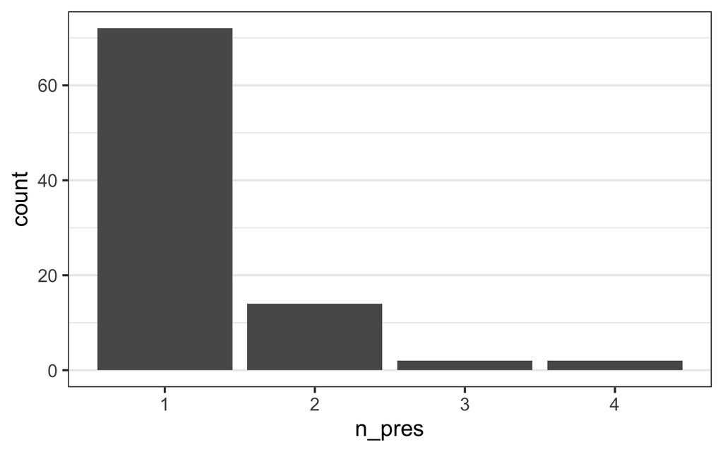

```r
ggplot(multi, aes(n_pres)) +
    geom_bar()
```

This is less likely when the memory strength for the first-seen image is low.

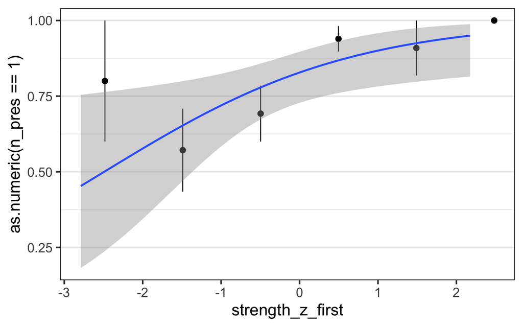

```r
ggplot(multi, aes(strength_z_first, as.numeric(n_pres == 1))) +
    stat_summary_bin(bins=5) +
    stat_smooth(method="glm", method.args = list(family="binomial"))
```

```r
glmer(n_pres == 1 ~ strength_z_first + (1|wid), family='binomial', data=multi) %>% summ
```

| Fixed Effects | Fixed Effects Est. | Fixed Effects S.E. | Fixed Effects z val. | Fixed Effects p |
| --- | --- | --- | --- | --- |
| (Intercept) | 1.888 | 0.534 | 3.535 | 0.000 |
| strength_z_first | 0.771 | 0.307 | 2.515 | 0.012 |

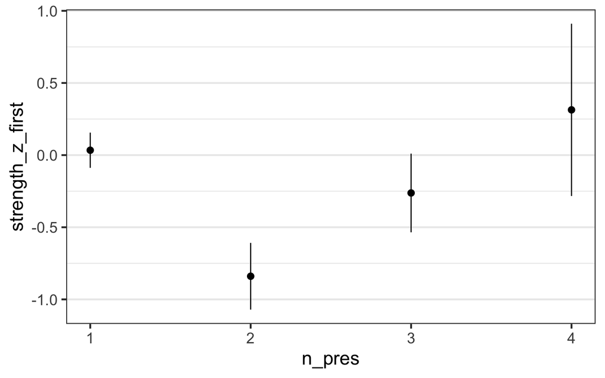

```r
ggplot(multi, aes(n_pres, strength_z_first)) +
    stat_summary()
```

## First presentation duration

The previous result could be taken as evidence of rational memory search, but it could also just be the result of recall being terminated quickly because the memory is strong.

Here’s a stronger test. Consider only the trials with more than one presentation. Do participants switch away from the first image more quickly when they have a worse memory of it?

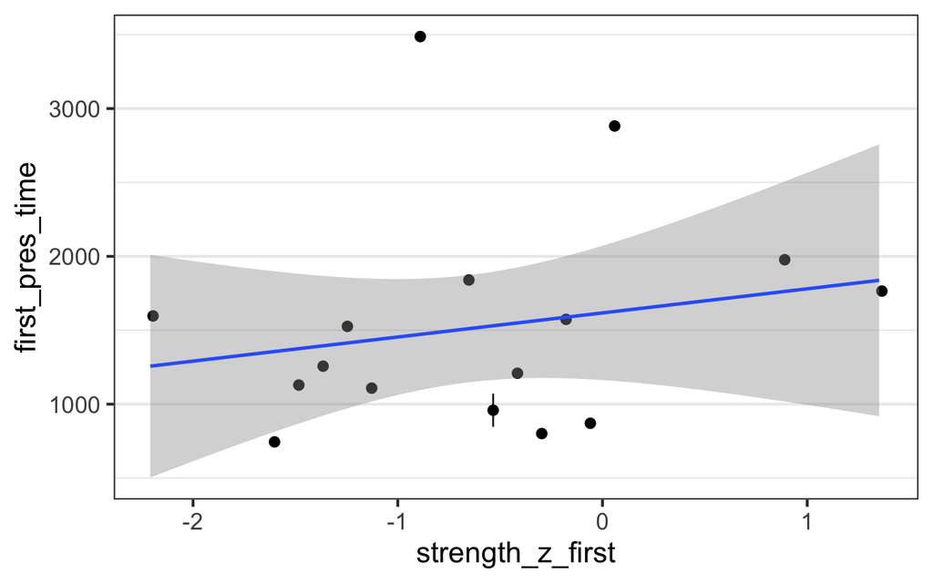

```r
multi %>%
    filter(n_pres > 1) %>%
    ggplot(aes(strength_z_first, first_pres_time)) +
        stat_summary_bin() +
        geom_smooth(method='lm')
```

```r
lmer(first_pres_time ~ strength_z_first + (1|wid), data=multi) %>% summ
```

| Fixed Effects | Fixed Effects Est. | Fixed Effects S.E. | Fixed Effects t val. | Fixed Effects d.f. | Fixed Effects p |
| --- | --- | --- | --- | --- | --- |
| (Intercept) | 1204.693 | 98.446 | 12.237 | 9.047 | 0.000 |
| strength_z_first | -48.740 | 53.528 | -0.911 | 81.442 | 0.365 |

p values calculated using Satterthwaite d.f.

## Reaction time

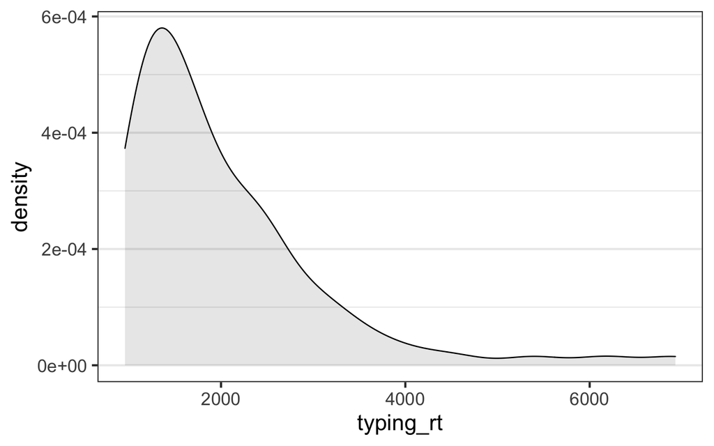

```r
multi %>%
    ggplot(aes(typing_rt)) +
        geom_density(fill="black", alpha=0.1)
```

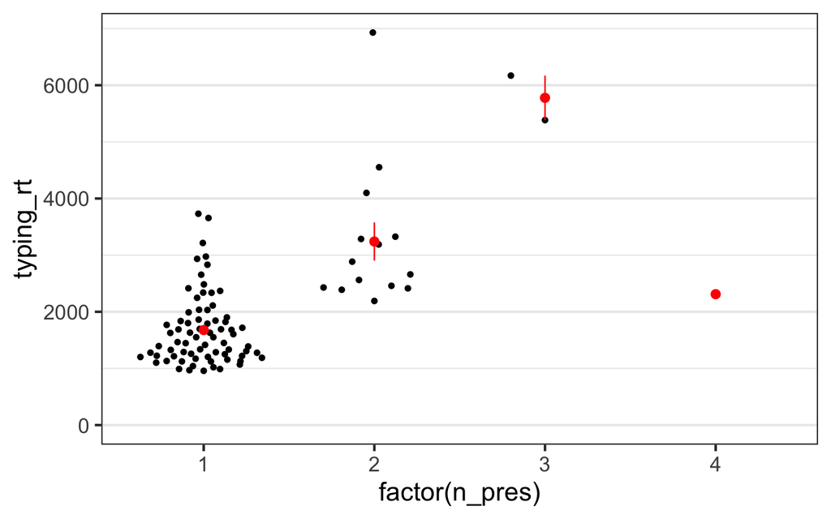

```r
multi %>%
    ggplot(aes(factor(n_pres), typing_rt)) +
        geom_quasirandom() +
        stat_summary(color="red") + ylim(0, NA)
```

```r
# multi %>% filter(wid == first(participants$wid)) %>%
#     select(strength_first, strength_second, abs(first_advantage)) %>%
#     arrange(`abs(first_advantage)`) %>%
#     pivot_longer(c(strength_first, strength_second)) %>%
#     ggplot()
# Check javascript score computation
check_score <- participants %>%
    select(wid, afc_scores) %>%
    json_to_columns(afc_scores) %>%
    pivot_longer(-wid, names_to="word") %>%
    mutate(js_strength = -value) %>%
    inner_join(afc_scores)

# max(check_score$js_score - check_score$score)
stopifnot(mean(check_score$js_strength - check_score$strength) < .1)
```